# Modelaje Epidemiológico en `R`

## Ejercicios

### R Básico

1. Utiliza la función `quantile` (con la opción `na.rm = T`) para calcular los cuantiles `0.975` y `0.025` y agrega dos líneas verticales a la gráfica anterior indicando los valores de los cuantiles junto con sus etiquetas:

```r
#Agregamos indicadora del promedio
q025 <- quantile(datos_diabetes$chol, 0.025, na.rm = T)
q975 <- quantile(datos_diabetes$chol, 0.975, na.rm = T)
```

```r
ggplot(datos_diabetes) +
  geom_histogram(aes(x = chol, y = ..density..), binwidth = 10,
                 fill = "#cef0ff",  color = "#1D1B1B") +
  geom_density(aes(x = chol), color = "deepskyblue4",
               linetype = "dotted", size = 1) +
  labs(
    x        = "Colesterol",
    y        = "",
    title    = "Distribución observada de los niveles de colesterol",
    subtitle = "Población afroamericana de Virginia"
  ) +
  theme_bw() +
  geom_vline(aes(xintercept = promedio_colesterol),
             color = "tomato3", linetype = "dashed", size = 1) +
  geom_vline(aes(xintercept = q025),
             color = "tomato3", linetype = "dashed", size = 1) +
  geom_vline(aes(xintercept = q975),
             color = "tomato3", linetype = "dashed", size = 1) +
  annotate("label", x = promedio_colesterol, y = 0.0001, label = "Media = 208",
           color = "tomato3") +
  annotate("label", x = q025, y = 0.0001, label = "2.5% = ???",
           color = "tomato3") +
  annotate("label", x = q975, y = 0.0001, label = "97.5% = ???",
           color = "tomato3") +
  scale_y_continuous(labels = scales::label_percent())
```

```
## Error in `f()`:
## ! Aesthetics must be valid data columns. Problematic aesthetic(s): x = chol.
## Did you mistype the name of a data column or forget to add after_stat()?
```

[output not shown]

3. Considera la siguiente base de datos:

```r
mis.datos <- data.frame(
  x = c(1.03, 1.24, 1.47, 1.52, 1.92, 1.93, 1.94, 1.95, 1.96, 1.97,
       1.98, 1.99, 2.72, 2.75, 2.78, 2.81, 2.84, 2.87, 2.90, 2.93,
       2.96, 2.99, 3.60, 3.64, 3.66, 3.72, 3.77, 3.88, 3.91, 4.14,
       4.54, 4.77, 4.81, 5.62)
)
```

Realiza un histograma de la variable `x` dentro de `mis.datos` con `binwidth` a `0.75`:

1. ¿Podemos concluir la forma de la distribución a partir del histograma? Es decir ¿está centrada?

Minitab tiene un [blog](https://blog.minitab.com/blog/3-things-a-histogram-can-tell-you) sobre cuándo usar histogramas. ¿Puedes descubrir todos sus errores?

2. Realiza el mismo histograma pero ahora con un ancho de banda de `1.2`. ¿Y ahora?
4. Considera la siguiente [base de datos](https://stats.stackexchange.com/questions/51718/assessing-approximate-distribution-of-data-based-on-a-histogram):

```r
mis.datos <- data.frame(
  A =  c(3.15, 5.46, 3.28, 4.20, 1.98, 2.28, 3.12, 4.10, 3.42, 3.91,
         2.06, 5.53, 5.19, 2.39, 1.88, 3.43, 5.51, 2.54, 3.64, 4.33,
         4.85, 5.56, 1.89, 4.84, 5.74, 3.22, 5.52, 1.84, 4.31, 2.01,
         4.01, 5.31, 2.56, 5.11, 2.58, 4.43, 4.96, 1.90, 5.60, 1.92),
  B =  c(2.90, 5.21, 3.03, 3.95, 1.73, 2.03, 2.87, 3.85, 3.17, 3.66,
         1.81, 5.28, 4.94, 2.14, 1.63, 3.18, 5.26, 2.29, 3.39, 4.08,
         4.60, 5.31, 1.64, 4.59, 5.49, 2.97, 5.27, 1.59, 4.06, 1.76,
         3.76, 5.06, 2.31, 4.86, 2.33, 4.18, 4.71, 1.65, 5.35, 1.67),
  C =  c(2.65, 4.96, 2.78, 3.70, 1.48, 1.78, 2.62, 3.60, 2.92, 3.41,
         1.56, 5.03, 4.69, 1.89, 1.38, 2.93, 5.01, 2.04, 3.14, 3.83,
         4.35, 5.06, 1.39, 4.34, 5.24, 2.72, 5.02, 1.34, 3.81, 1.51,
         3.51, 4.81, 2.06, 4.61, 2.08, 3.93, 4.46, 1.4, 5.1, 1.42),
  D =  c(2.40, 4.71, 2.53, 3.45, 1.23, 1.53, 2.37, 3.35, 2.67, 3.16,
         1.31, 4.78, 4.44, 1.64, 1.13, 2.68, 4.76, 1.79, 2.89, 3.58,
         4.10, 4.81, 1.14, 4.09, 4.99, 2.47, 4.77, 1.09, 3.56, 1.26,
         3.26, 4.56, 1.81, 4.36, 1.83, 3.68, 4.21, 1.15, 4.85, 1.17)
)
```

Grafica un histograma de las variables `A`, `B`, `C` y `D` de dicha base con un ancho de banda (`binwidth`) igual a `1`:

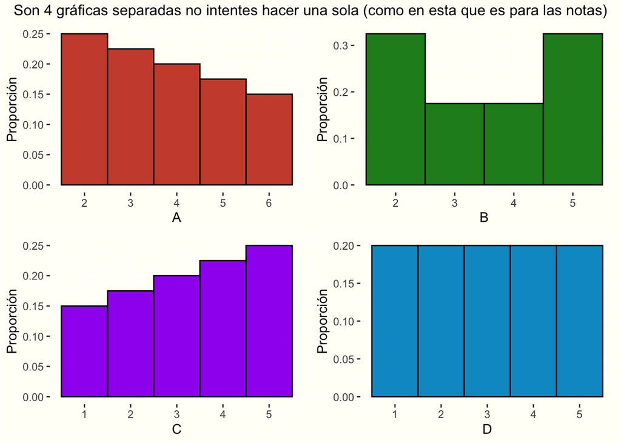

¿Podemos concluir la forma de la distribución a partir del histograma? Es decir ¿hay distribuciones sesgadas a la izquierda, a la derecha, uniformes, centradas o con colas pesadas?

Realiza el mismo histograma pero ahora con un ancho de banda de `0.25` ¿por qué hubo cambios? Analiza la base de datos (los valores en función de la columna `A`) y concluye.

## Gráficas de barras

El archivo `inegi_seguro_popular.csv` ([datos reales obtenidos de INEGI](https://datos.gob.mx/busca/dataset/porcentaje-de-la-poblacion-afiliada-al-seguro-popular-derecho-a-la-salud-recepcion-del-derecho)) contiene información del número de personas afiliadas al seguro popular por entidad federativa en 2010 y 2015. Graficaremos ambos años. Para ello, leamos el archivo:

```r
seguro.pop <- read_csv("inegi_seguro_popular.csv",
                       locale = locale(encoding = "WINDOWS-1252"))
```

Notarás que esta vez tuvimos que establecer un *locale* esto es porque la base tiene acentos y caracteres del español y cuando la base fue generada por una computadora `Windows` hay que especificar que viene de *Windows* con el locale.

El `locale` es un poco más complicado y refiere a cómo la computadora sabe qué secuencia de bits corresponde a qué caracter. Latinoamérica usualmente está entre `WINDOWS-1252` y `UTF-8`.

Podemos graficar los datos que aparecen en gráfica de barras mediante el comando `geom_col`:

```r
#Gráfica encimada
ggplot(seguro.pop) +
  geom_col(aes(x = `Entidad federativa`,
               y = `Porcentaje de la población afiliada al seguro popular`))
```

```
## Error in FUN(X[[i]], ...): object 'Entidad federativa' not found
```

Esta vez como los nombbres de las columnas contienen varias palabras hubo que colocarlas entre dos [acentos graves ó backticks:](https://en.wikipedia.org/wiki/Backtick) `` ` ``

```r
#Gráfica encimada con dos periodos
ggplot(seguro.pop) +
  geom_col(aes(x = `Entidad federativa`,
               y = `Porcentaje de la población afiliada al seguro popular`,
               fill = as.character(Periodo)))
```

```
## Error in FUN(X[[i]], ...): object 'Entidad federativa' not found
```

Ojo como `periodo` es una sola palabra podemos ponerlo con o sin el acento `` ` ``:

```r
#Gráfica encimada con dos periodos (equivalente)
ggplot(seguro.pop) +
  geom_col(aes(x = `Entidad federativa`,
               y = `Porcentaje de la población afiliada al seguro popular`,
               fill = as.character(`Periodo`)))
```

```
## Error in FUN(X[[i]], ...): object 'Entidad federativa' not found
```

Mediante `coord_flip()` podemos rotar las coordenadas:

```r
#Gráfica encimada
ggplot(seguro.pop) +
  geom_col(aes(x = `Entidad federativa`,
               y = `Porcentaje de la población afiliada al seguro popular`,
               fill = as.character(`Periodo`))) +
  coord_flip()
```

```
## Error in FUN(X[[i]], ...): object 'Entidad federativa' not found
```

```r
#Gráfica con position
ggplot(seguro.pop) +
  geom_col(aes(x = `Entidad federativa`,
               y = `Porcentaje de la población afiliada al seguro popular`,
               fill = as.character(`Periodo`)),
           position = "dodge") +
  coord_flip()
```

```
## Error in FUN(X[[i]], ...): object 'Entidad federativa' not found
```

o bien:

```r
ggplot(seguro.pop) +
  geom_col(aes(x = `Entidad federativa`,
               y = `Porcentaje de la población afiliada al seguro popular`,
               fill = as.character(`Periodo`))) +
  coord_flip() +
  facet_wrap(~ as.character(`Periodo`))
```

```
## Error in eval_tidy(facet, mask): object 'Periodo' not found
```

```r
#Gráfica colores mediante "scale_fill_manual"
ggplot(seguro.pop) +
  geom_col(aes(x = `Entidad federativa`,
               y = `Porcentaje de la población afiliada al seguro popular`,
               fill = as.character(`Periodo`))) +
  coord_flip() +
  facet_wrap(~ as.character(`Periodo`)) +
  scale_fill_manual("Año",
                    values = c("2010" = "#EB2188",  #colores del 2010
                               "2015" = "#080A52")) #colores del 2015
```

```
## Error in eval_tidy(facet, mask): object 'Periodo' not found
```

Podemos reordenar el eje para que `Aguascalientes` quede hasta arriba. Para eso especificamos el orden. Lo podemos hacer manualmente (pero qué flojera):

```r
orden <- c('Estados Unidos Mexicanos', 'Aguascalientes', 'Baja California',
           'Baja California Sur', 'Campeche', 'Coahuila de Zaragoza',
           'Colima', 'Chiapas', 'Chihuahua', 'Ciudad de México', 'Durango',
           'Guanajuato', 'Guerrero', 'Hidalgo', 'Jalisco', 'México',
           'Michoacán de Ocampo', 'Morelos', 'Nayarit', 'Nuevo León',
           'Oaxaca', 'Puebla', 'Querétaro', 'Quintana Roo', 'San Luis Potosí',
           'Sinaloa', 'Sonora', 'Tabasco', 'Tamaulipas', 'Tlaxcala',
           'Veracruz de Ignacio de la Llave', 'Yucatán', 'Zacatecas')
```

O bien pidiéndole a `R` una lista de los estados en la base:

```r
orden <- unique(seguro.pop$`Entidad federativa`)
```

en cualquiera de los casos esa lista la pondremos en reversa dentro de limits:

```r
#Reordenamos el eje vertical
ggplot(seguro.pop) +
  geom_col(aes(x = `Entidad federativa`,
               y = `Porcentaje de la población afiliada al seguro popular`,
               fill = as.character(`Periodo`))) +
  coord_flip() +
  facet_wrap(~ as.character(`Periodo`)) +
  scale_fill_manual("Año",
                    values = c("2010" = "#EB2188",
                               "2015" = "#080A52")) +
  scale_x_discrete(limits = rev(orden))
```

```
## Error in eval_tidy(facet, mask): object 'Periodo' not found
```

Finalmente, podemos agregar los formatos de etiquetas usuales:

```r
ggplot(seguro.pop) +
  geom_col(aes(x = `Entidad federativa`,
               y = `Porcentaje de la población afiliada al seguro popular`,
               fill = as.character(`Periodo`))) +
  coord_flip() +
  facet_wrap(~ as.character(`Periodo`)) +
  scale_fill_manual("Año",
                    values = c("2010" = "#EB2188",
                               "2015" = "#080A52")) +
  scale_x_discrete(limits = rev(orden)) +
  labs(
    title   = "Población afiliada al Seguro Popular\npor entidad federativa",
    y       = "Proporción de la población",
    x       = "Entidad federativa",
    caption = "Fuente: INEGI"
  ) +
  theme_bw()
```

```
## Error in eval_tidy(facet, mask): object 'Periodo' not found
```

## Ejercicio

1. El siguiente código genera una base de datos de nombre `vacunacion` con la información de cuántos niños menores de uno o dos años tienen el esquema completo de cuatro vacunas de acuerdo con las distintas Encuestas Nacionales de Salud ENSA/ENSANUT.

```r
Encuesta   <- rep(c("2000","2006","2012","2018-19","2021"), 2)
vacperc    <- c(c(0.265, 0.784, 0.742, 0.199, 0.311), c(0.5, 0.847, 0.779, 0.353, 0.358))
clase      <- c(rep("1 año cumplido", 5), rep("2 años cumplidos", 5))

vacunacion           <- data.frame(Encuesta, vacperc, clase)
colnames(vacunacion) <- c("ENSANUT", "Porcentaje vacunado", "Edad de los niños")
```

Grafica los datos con columnas.

# Gráficas de trayectorias

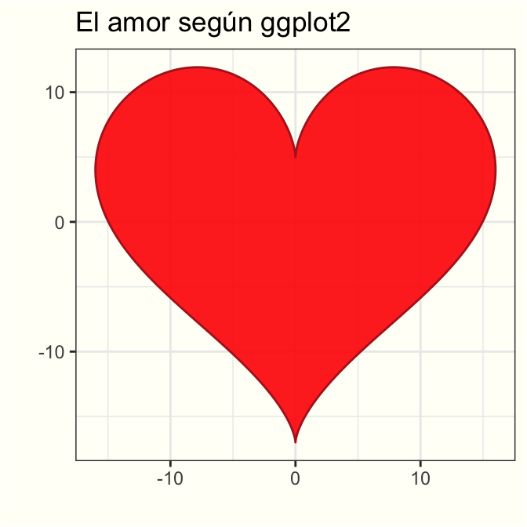

En ggplot2 puedes graficar lo que quieras. Hasta puedes declarar tu amor. Este próximo 14 de febrero usa ggplot2.

Grafiquemos la cantidad de casos totales en México como puntos

```r
ggplot(sinave) +
  geom_point(aes(x = FECHA_SINTOMAS, y = n), color = "#f162ff")
```

```
## Error in FUN(X[[i]], ...): object 'FECHA_SINTOMAS' not found
```

```r
ggplot(sinave) +
  geom_point(aes(x = FECHA_SINTOMAS, y = n), color = "#f162ff") +
  geom_spline(aes(x = FECHA_SINTOMAS, y = n), color = "#ffd79d")
```

```
## Error in geom_spline(aes(x = FECHA_SINTOMAS, y = n), color = "#ffd79d"): could not find function "geom_spline"
```

podemos mejor usar la función `geom_spline` del paquete `ggformula` para usar una línea que se encargue de eliminar el ruido de los datos y descubrir la forma inherente:

```r
library(ggformula)

ggplot(sinave) +
  geom_point(aes(x = FECHA_SINTOMAS, y = n), color = "#f162ff") +
  geom_spline(aes(x = FECHA_SINTOMAS, y = n), color = "#ffd79d")
```

```
## Error in FUN(X[[i]], ...): object 'FECHA_SINTOMAS' not found
```

```r
ggplot(sinave) +
  geom_point(aes(x = FECHA_SINTOMAS, y = n), color = "#f162ff") +
  geom_spline(aes(x = FECHA_SINTOMAS, y = n, color = "df 900"), df = 900) +
  geom_spline(aes(x = FECHA_SINTOMAS, y = n, color = "df 45"), df = 45) +
  geom_spline(aes(x = FECHA_SINTOMAS, y = n, color = "df 20"), df = 15)  +
  geom_spline(aes(x = FECHA_SINTOMAS, y = n, color = "df 5"), df = 10)
```

```
## Error in FUN(X[[i]], ...): object 'FECHA_SINTOMAS' not found
```

```r
ggplot(sinave) +
  geom_point(aes(x = FECHA_SINTOMAS, y = n), color = "#f162ff") +
  geom_spline(aes(x = FECHA_SINTOMAS, y = n), color = "#ffd79d", df = 45)
```

```
## Error in FUN(X[[i]], ...): object 'FECHA_SINTOMAS' not found
```

Lo que sigue es personalizar la gráfica poniendo los títulos, el tema y cambiando los ejes a tener notación con comas. Todo esto lo hemos hecho antes:

```r
ggplot(sinave) +
  geom_point(aes(x = FECHA_SINTOMAS, y = n), color = "#f162ff") +
  geom_spline(aes(x = FECHA_SINTOMAS, y = n), color = "#ffd79d", df = 45) +
  labs(
    x        = "",
    y        = "Casos incidentes",
    title    = "Enfermedades Respiratorias",
    subtitle = "Registros del Sistema Nacional de Vigilancia Epidemiológica (SINAVE)",
    caption  = "Datos Abiertos de la Dirección General de Epidemiología"
  ) +
  scale_y_continuous(labels = scales::label_comma())
```

```
## Error in FUN(X[[i]], ...): object 'FECHA_SINTOMAS' not found
```

Agregaré un `scale_x_date` para elegir tener cortes en el eje `x` cada 6 meses y:

```r
ggplot(sinave) +
  geom_point(aes(x = FECHA_SINTOMAS, y = n), color = "#f162ff") +
  geom_spline(aes(x = FECHA_SINTOMAS, y = n), color = "#ffd79d", df = 45) +
  labs(
    x        = "",
    y        = "Casos incidentes",
    title    = "Enfermedades Respiratorias",
    subtitle = "Registros del Sistema Nacional de Vigilancia Epidemiológica (SINAVE)",
    caption  = "Datos Abiertos de la Dirección General de Epidemiología"
  ) +
  scale_y_continuous(labels = scales::label_comma()) +
  scale_x_date(date_breaks = "6 months", date_minor_breaks = "3 months",
               date_labels = "%b/%Y") +
  theme_bw()
```

```
## Error in FUN(X[[i]], ...): object 'FECHA_SINTOMAS' not found
```

Utilizaremos `theme` para realizar cambios a cada parte de la gráfica comenzando por cambiar el color de fondo:

```r
ggplot(sinave) +
  geom_point(aes(x = FECHA_SINTOMAS, y = n), color = "#f162ff") +
  geom_spline(aes(x = FECHA_SINTOMAS, y = n), color = "#ffd79d", df = 45) +
  labs(
    x        = "",
    y        = "Casos incidentes",
    title    = "Enfermedades Respiratorias",
    subtitle = "Registros del Sistema Nacional de Vigilancia Epidemiológica (SINAVE)",
    caption  = "Datos Abiertos de la Dirección General de Epidemiología"
  ) +
  scale_y_continuous(labels = scales::label_comma()) +
  scale_x_date(date_breaks = "6 months", date_minor_breaks = "3 months",
               date_labels = "%b/%Y") +
  theme_classic() +
  theme(
    panel.background = element_rect(fill = "#320d3e")
  )
```

```
## Error in FUN(X[[i]], ...): object 'FECHA_SINTOMAS' not found
```

```r
ggplot(sinave) +
  geom_point(aes(x = FECHA_SINTOMAS, y = n), color = "#f162ff") +
  geom_spline(aes(x = FECHA_SINTOMAS, y = n), color = "#ffd79d", df = 45) +
  labs(
    x        = "",
    y        = "Casos incidentes",
    title    = "Enfermedades Respiratorias",
    subtitle = "Registros del Sistema Nacional de Vigilancia Epidemiológica (SINAVE)",
    caption  = "Datos Abiertos de la Dirección General de Epidemiología"
  ) +
  scale_y_continuous(labels = scales::label_comma()) +
  scale_x_date(date_breaks = "6 months", date_minor_breaks = "3 months",
               date_labels = "%b/%Y") +
  theme_classic() +
  theme(
    panel.background = element_rect(fill = "#320d3e"),                  #Fondo de la gráfica
    plot.background  = element_rect(fill = "green"),                    #Fondo de los títulos
    axis.text.x      = element_text(color = "red", size = 5),           #Letras de los ejes
    axis.text.y      = element_text(color = "forestgreen"),             #Letras de los ejes
    axis.ticks       = element_line(color = "red", size = 2),           #Los | abajo de los ejes
    axis.line.x      = element_line(color = "orange", size = 2),        #Línea del eje
    axis.line.y      = element_line(color = "yellow", size = 3),        #Otra línea del eje
    plot.title       = element_text(color = "blue", size = 20),         #Título
    plot.subtitle    = element_text(color = "gray25", face = "italic"), #Subtítulo
    plot.caption     = element_text(color = "purple"),                  #Caption
    axis.title.y     = element_text(color = "pink"),                    #Lo que dice el eje y
  )
```

```
## Error in FUN(X[[i]], ...): object 'FECHA_SINTOMAS' not found
```

La cual podemos arreglar rápidamente con una mezcla amigable de colores:

```r
ggplot(sinave) +
  geom_point(aes(x = FECHA_SINTOMAS, y = n), color = "#007677") +
  geom_spline(aes(x = FECHA_SINTOMAS, y = n), color = "#ffd79d", df = 45) +
  labs(
    x        = "",
    y        = "Casos incidentes",
    title    = "Enfermedades Respiratorias",
    subtitle = "Registros del Sistema Nacional de Vigilancia Epidemiológica (SINAVE)",
    caption  = "Datos Abiertos de la Dirección General de Epidemiología"
  ) +
  scale_y_continuous(labels = scales::label_comma()) +
  scale_x_date(date_breaks = "6 months", date_minor_breaks = "3 months",
               date_labels = "%b/%Y") +
  theme_classic() +
  theme(
    panel.background = element_rect(fill = "#003f5c"),                   #Fondo de la gráfica
    plot.background  = element_rect(fill = "#003f5c", color = "black"),  #Fondo de los títulos
    axis.text.x      = element_text(color = "gray75"),                   #Letras de los ejes
    axis.text.y      = element_text(color = "gray75"),                   #Letras de los ejes
    axis.ticks       = element_line(color = "gray75"),                   #Los | abajo de los ejes
    axis.line.x      = element_line(color = "gray75"),                   #Línea del eje
    axis.line.y      = element_line(color = "gray75"),                   #Otra línea del eje
    plot.title       = element_text(color = "gray75", size = 25),        #Título
    plot.subtitle    = element_text(color = "#62a757", face = "italic"), #Subtítulo
    plot.caption     = element_text(color = "#62a757"),                  #Caption
    axis.title.y     = element_text(color = "gray75"),                   #Lo que dice el eje y
  )
```

```
## Error in FUN(X[[i]], ...): object 'FECHA_SINTOMAS' not found
```

y finalmente podemos agregar anotaciones:

```r
ggplot(sinave) +
  geom_point(aes(x = FECHA_SINTOMAS, y = n), color = "#007677") +
  geom_spline(aes(x = FECHA_SINTOMAS, y = n), color = "#ffd79d", df = 45) +
  labs(
    x        = "",
    y        = "Casos incidentes",
    title    = "Enfermedades Respiratorias",
    subtitle = "Registros del Sistema Nacional de Vigilancia Epidemiológica (SINAVE)",
    caption  = "Datos Abiertos de la Dirección General de Epidemiología"
  ) +
  scale_y_continuous(labels = scales::label_comma()) +
  scale_x_date(date_breaks = "6 months", date_minor_breaks = "3 months",
           date_labels = "%b/%Y") +
  theme_classic() +
  theme(
    panel.background = element_rect(fill = "#003f5c"),                   #Fondo de la gráfica
    plot.background  = element_rect(fill = "#003f5c", color = "black"),  #Fondo de los títulos
    axis.text.x      = element_text(color = "gray75"),                   #Letras de los ejes
    axis.text.y      = element_text(color = "gray75"),                   #Letras de los ejes
    axis.ticks       = element_line(color = "gray75"),                   #Los | abajo de los ejes
    axis.line.x      = element_line(color = "gray75"),                   #Línea del eje
    axis.line.y      = element_line(color = "gray75"),                   #Otra línea del eje
    plot.title       = element_text(color = "gray75", size = 25),        #Título
    plot.subtitle    = element_text(color = "#62a757", face = "italic"), #Subtítulo
    plot.caption     = element_text(color = "#62a757"),                  #Caption
    axis.title.y     = element_text(color = "gray75"),                   #Lo que dice el eje y
  ) +
  #Anotaciones
  geom_point(aes(x = as.Date("2020/02/28"), y = 1), color = "gray75", data = NULL, size = 2) +
  geom_segment(aes(x = as.Date("2020/02/28"), xend = as.Date("2020/02/28"), y = 1,
                   yend = 75000), color = "gray75") +
  geom_point(aes(x = as.Date("2020/02/28"), y = 75000), color = "gray75", data = NULL, size = 2) +
  annotate("text", x = as.Date("2020/03/15"), y = 75000, hjust = 0,
           label = "Primer caso de COVID-19", color = "gray75")
```

```
## Error in FUN(X[[i]], ...): object 'FECHA_SINTOMAS' not found
```

## Ejercicios

# Ejercicios de cierre de la sección

> Para este ejercicio puedes usar cualquier base(s) de datos que tú desees. Si no se te ocurre ninguna te recomendamos usar `ile-2019-2021.csv` que contiene los registros de interrupciones legales del embarazo en Ciudad de México o bien `linea-mujeres.csv` que contiene información sobre las llamadas realizadas a la Línea Mujeres de la Ciudad de México hasta noviembre del 2020.

El ejercicio consiste en realizar dos gráficas de distinto tipo (*ej* una de barras y una de tendencia) analizando elementos de tu base de datos.

- En la siguiente liga puedes encontrar código de `R` para generar 50 tipos distintos de gráficas: http://r-statistics.co/Top50-Ggplot2-Visualizations-MasterList-R-Code.html
- En esta otra liga puedes encontrar otros paquetes de graficación que se apoyan sobre `ggplot2` para hacer más gráficas: https://exts.ggplot2.tidyverse.org/gallery/.
- Finalmente checa las paletas de colores prediseñadas en paquetes de `R` como [`wesanderson`](https://github.com/karthik/wesanderson) o [`MetBrewer`](https://github.com/BlakeRMills/MetBrewer) así como la de [Harry Potter](https://github.com/aljrico/harrypotter).

## Continuación

¡Felicidades! Ya terminaste esta sección. Puedes ir a:

- Bases de datos y análisis descriptivo en `R`.

# Para saber más

El [libro de `ggplot2`](https://ggplot2-book.org/) es una excelente referencia para la parte de graficación así como [las notas en español de `rafalab`](https://rafalab.github.io/dslibro/ggplot2.html). Por otro lado el libro de [Fundamentals of Data Visualization](https://clauswilke.com/dataviz/) analiza más a fondo cómo presentar datos de formas que convenzan al público. Para armar historias a partir de los datos ve el libro de [Story-telling with data](https://www.storytellingwithdata.com/books)